# EDA

Nancy Lin

3/30/2020

```r
library(readxl)
library(tidyverse)
```

```r
library(ggplot2)
```

```r
# t101 <- read_csv("101a1a2.csv", locale = locale(encoding = 'BIG5'))
# t101 %>%
#   mutate(肇事地點=iconv(肇事地點, from = "BIG5", to = "UTF-8"))
t101 <- read.table("101a1a2.csv", header=TRUE,sep = ",", fileEncoding = "BIG5")
t102 <- read.table("102a1a2.csv", header=TRUE,sep = ",", fileEncoding = "BIG5")
t103 <- read.table("103a1a2.csv", header=TRUE,sep = ",", fileEncoding = "BIG5")
# t104 <- read.table("104a1a2.csv", header=TRUE,sep = ",", fileEncoding = "BIG5")
t105 <- read.table("105a1a2.csv", header=TRUE,sep = ",", fileEncoding = "BIG5")
t106 <- read.table("106a1a2.csv", header=TRUE,sep = ",", fileEncoding = "BIG5")

# t101 <- na.omit(t101)
# t102 <- na.omit(t102)
# t103 <- na.omit(t103)
# t104 <- na.omit(t104)
# t105 <- na.omit(t105)
# t106 <- na.omit(t106)

t <-rbind(t101, t102, t103, t105, t106)
#t <-rbind(t101, t102, t103, t104, t105, t106)
```

# Data Cleaning

```r
t <- t %>%
  rename(
    year = 發生年,
    month = 發生月,
    mday = 發生日,
    hour = 發生時,
    minute = 發生分,
    die24hr = 處理別,
    district = 區序,
    address = 肇事地點,
    dead = 死亡人數,
    injured = 受傷人數,
    perp = 當事人序,
    cartype = 車種,
    gender = 性別,
    age = 年齡,
    injuredstatus = 受傷程度,
    weather = 天候,
    speedlimit = 速限,
    roadtype = 道路型態,
    location = 事故位置
    )
```

```r
t$year[t$year==101] <- 2012
t$year[t$year==102] <- 2013
t$year[t$year==103] <- 2014
t$year[t$year==104] <- 2015
t$year[t$year==105] <- 2016
t$year[t$year==106] <- 2017
t$speedlimit[t$speedlimit==440] <- 40
t$speedlimit[t$speedlimit==1] <- 10
t$speedlimit[t$speedlimit==2] <- 20
t$speedlimit[t$speedlimit==3] <- 30
t$speedlimit[t$speedlimit==4] <- 40
t$speedlimit[t$speedlimit==5] <- 50
t$speedlimit[t$speedlimit==58] <- 60
t$speedlimit[t$speedlimit<=29 & t$speedlimit>0] <- 40
t$speedlimit[t$speedlimit==0] <- 200
t$age[t$age>=200 | t$age<0] <- NA
t <- na.omit(t)
```

```r
t <- t %>%
   mutate(agesec = case_when(age>=0 & age<12 ~ "0-11",
                             age>=12 & age<18 ~ "12-17",
                             age>=18 & age<22 ~ "18-21",
                             age>=22 & age<30 ~ "22-29",
                             age>=30 & age<40 ~ "30-39",
                             age>=40 & age<50 ~ "40-49",
                             age>=50 & age<60 ~ "50-59",
                             age>=60 & age<70 ~ "60-69",
                             age>=70 & age<80 ~ "70-79",
                             age>=80 & age<90 ~ "80-89",
                             age>=90 & age<100 ~ "90-99",
                             age>=100 ~ "100-"))
```

```r
cfactor <- c("year", "month", "mday", "hour", "minute", "die24hr", "dead", "injured", "perp", "cartype", "gender", "injuredstatus", "weather", "speedlimit", "roadtype", "location", "agesec")
t[cfactor] <- lapply(t[cfactor], as.factor)
summary(t)
```

```
##    year           month             mday             hour
##  2012:42849   12     : 22289   5      :  7904   8      : 19219
##  2013:44667   1      : 20598   25     :  7890   18     : 16006
##  2014:46043   11     : 20330   6      :  7864   17     : 15643
##  2016:50304   10     : 20205   7      :  7801   9      : 15156
##  2017:49596   3      : 19862   13     :  7798   16     : 13416
##               5      : 19472   26     :  7796   15     : 12932
##               (Other):110703   (Other):186406   (Other):141087
##      minute       die24hr        district
##  30     : 21434   1:   875   03中山區:29686
##  0      : 20853   2:232584   09北投區:24126
##  50     : 16130              10文山區:22977
##  40     : 15362              05中正區:22906
##  20     : 14985              07信義區:22399
##  10     : 13553              12內湖區:22137
##  (Other):131142              (Other) :89228
##                            address       dead          injured
##  中正區中華路1段與忠孝西路1段口:   189   0:232584   1      :157778
##  中正區中山南路與信義路1段口   :   171   1:   838   2      : 58760
##  延平北路 民權西路             :   154   2:    12   3      : 12462
##  北投區大度路3段與中央北路4段口:   150   4:    25   4      :  2832
##  文山區木柵路2段與興隆路4段口  :   138              5      :   535
##  文山區                        :   133              0      :   506
##  (Other)                       :232524              (Other):   586
##       perp           cartype       gender          age
##  2      :102867   C03    :111978   1:161718   Min.   :  0.00
##  1      :102405   B03    : 46881   2: 70847   1st Qu.: 24.00
##  3      : 22740   H02    : 16885   3:    59   Median : 36.00
##  4      :  3831   B01    : 16047   4:   835   Mean   : 39.05
##  5      :   930   H01    : 11652              3rd Qu.: 52.00
##  6      :   307   C04    :  6790              Max.   :157.00
##  (Other):   379   (Other): 23226
##  injuredstatus weather      speedlimit        roadtype
##  1:   395      1:   164   50     :166084   4      :92393
##  2:140714      2:    27   40     : 36698   14     :66483
##  3: 85739      3:     1   30     : 13765   3      :52669
##  4:  6606      4:    21   200    : 12248   5      : 7826
##  5:     5      6: 39486   60     :  3527   11     : 3567
##                7: 40803   70     :   873   8      : 2794
##                8:152957   (Other):   264   (Other): 7727
##     location          agesec
##  1      :106219   22-29  :46639
##  9      : 60394   30-39  :43779
##  2      : 42849   40-49  :36984
##  8      :  6247   50-59  :35742
##  7      :  6146   18-21  :32448
##  22     :  3970   60-69  :21339
##  (Other):  7634   (Other):16528
```

# EDA

```r
p <- ggplot(data = t)
```

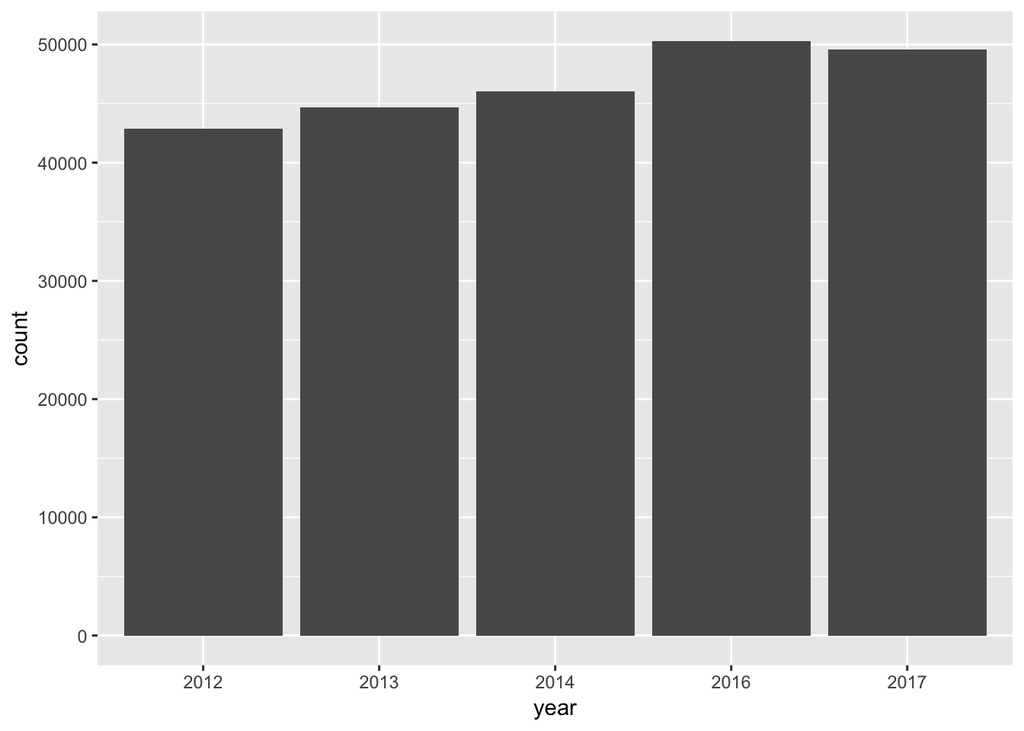

```r
p + geom_bar(aes(x = year))
```

The number of traffic accidents in Taipei slightly increases from 2012 to 2017.

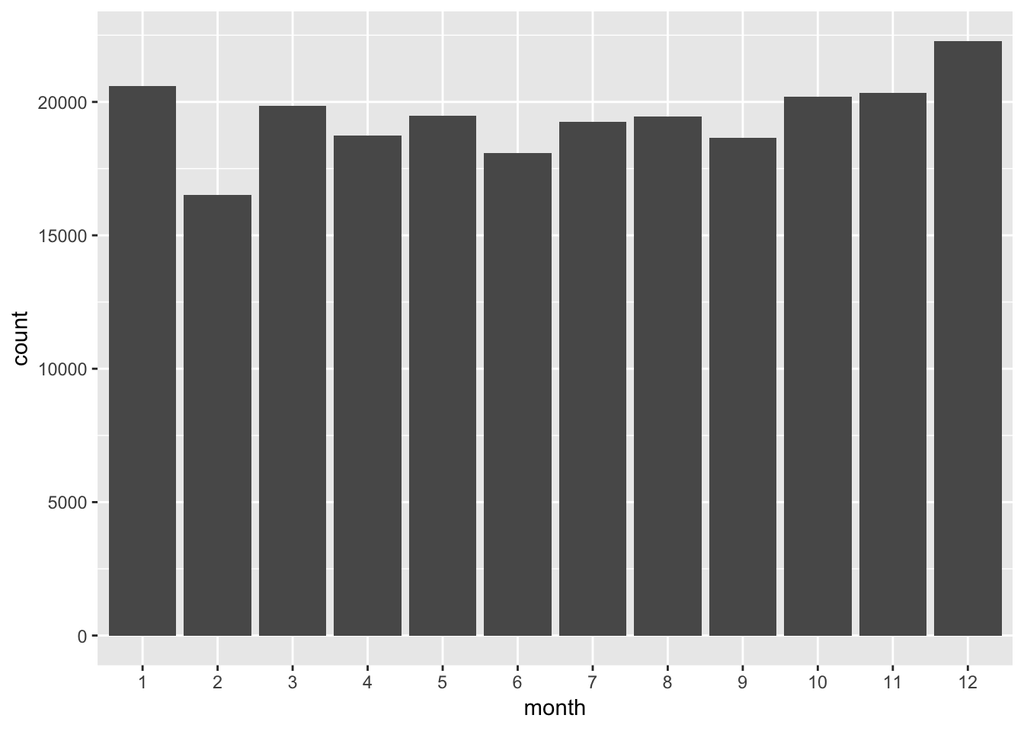

```r
p + geom_bar(aes(x = month))
```

The number of traffic accidents in Taipei is quite average each month. In December occur more accidents, which might result from the crazy traffic during Christmas and New Year’s Eve in Taipei for celebration. In February occur less accidents, which might result from the Lunar New Year Holidays, when most of the people living or working in Taipei have to go back to their hometown in other places in Taiwan, leaving Taipei a nearly empty town.

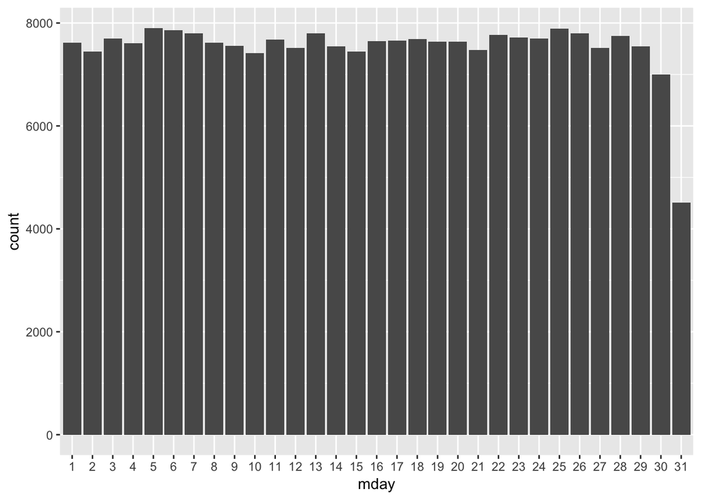

```r
p + geom_bar(aes(x = mday))
```

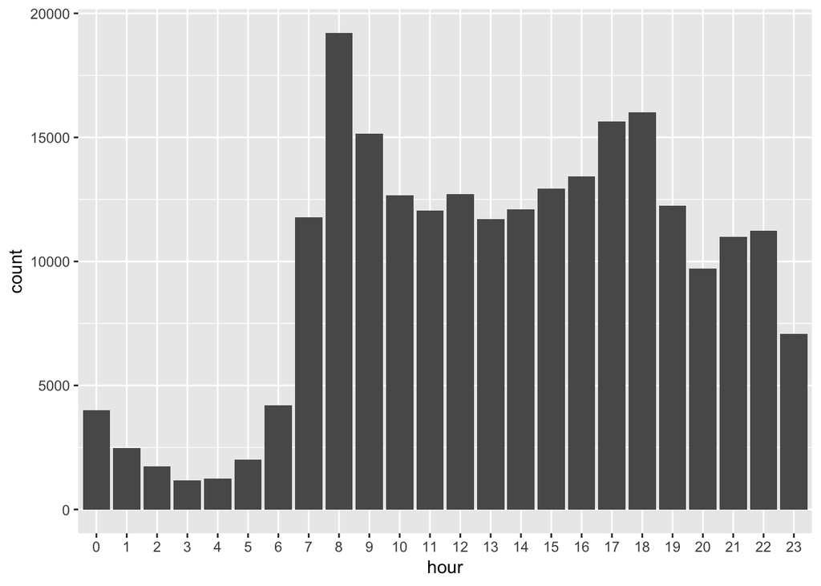

```r
p + geom_bar(aes(x = hour))
```

Traffic accidents happen the most at 8 a.m. and 6 p.m., which might result from the rush hour for commuting to and from work. Traffic accidents happen the least from 12 a.m. to 6 a.m, when most of people are sleeping.

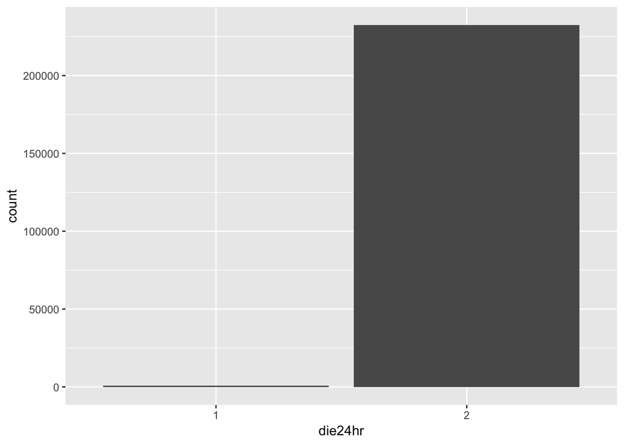

```r
p + geom_bar(aes(x = die24hr))
```

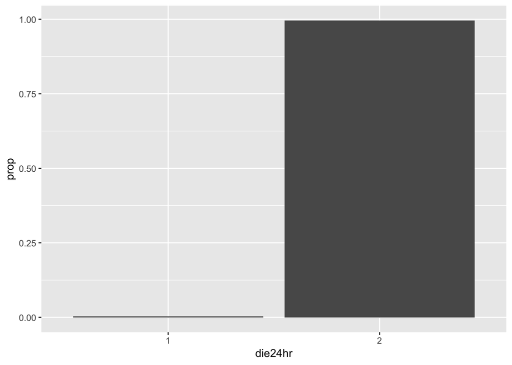

```r
p + geom_bar(aes(x = die24hr, y = stat(prop), group = 1))
```

Most of the traffic accidents do not cause people die within 24 hours.

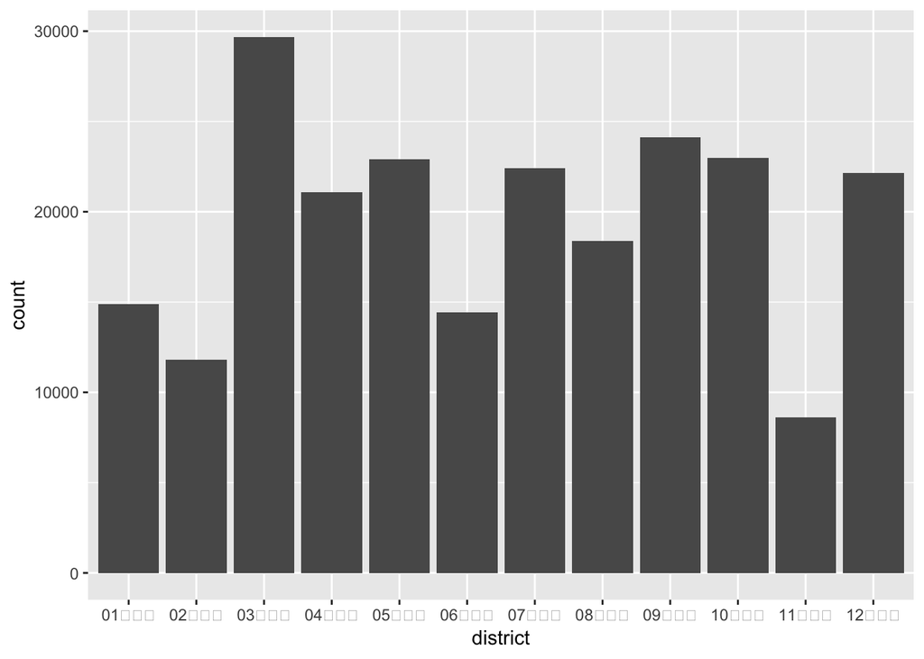

```r
p + geom_bar(aes(x = district))
```

Highest 1st: 03中山區 The commercial area and the center of Taipei. 2nd: 09北投區 An inner suburb of Taipei with a wide area of montains.

Lowest 1st: 11南港區 The industrial area of Taipei with small numbers of residents. 2nd: 02萬華區 The old prosperous area of Taipei.

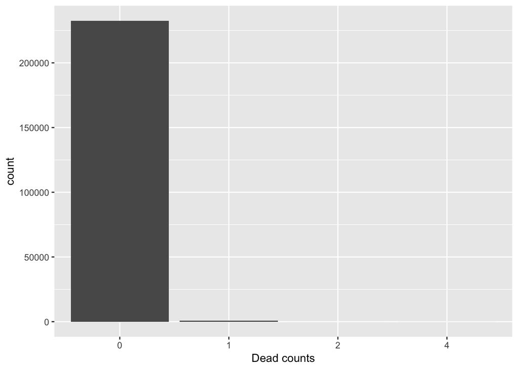

```r
p + geom_bar(aes(x = dead)) + xlab("Dead counts")
```

Most of the traffic accidents do not cause any death.

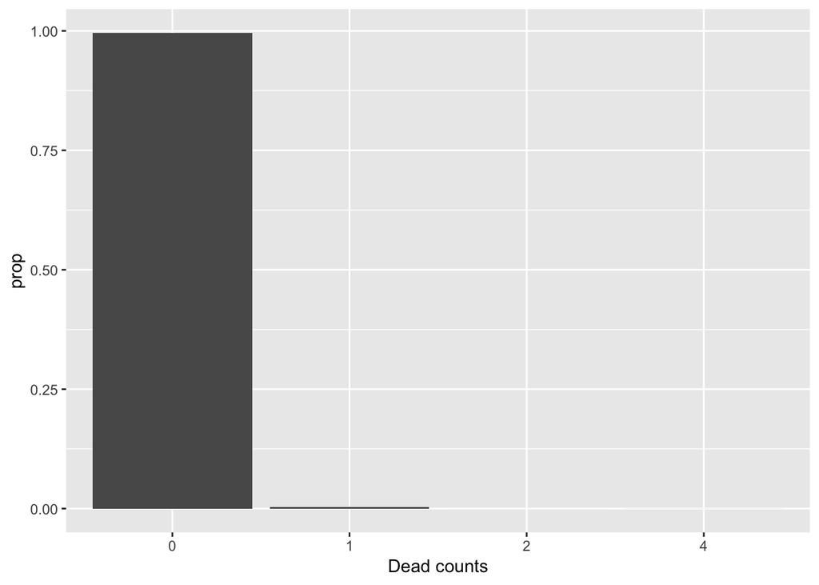

```r
p + geom_bar(aes(x = dead, y = stat(prop), group = 1)) + xlab("Dead counts")
```

Most of the traffic accidents do not cause any death.

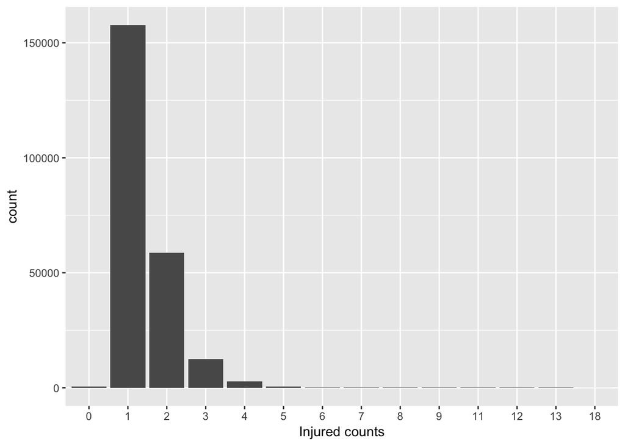

```r
p + geom_bar(aes(x = injured)) + xlab("Injured counts")
```

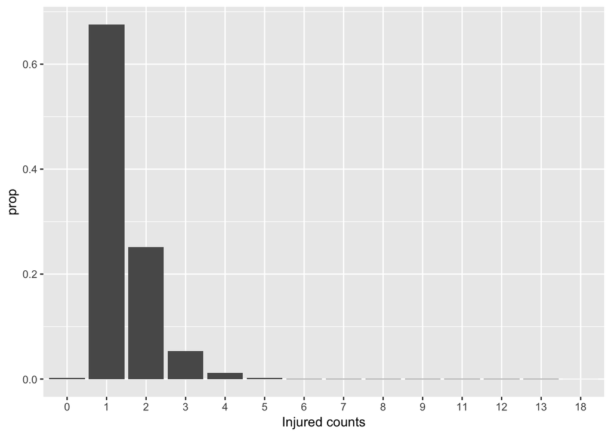

```r
p + geom_bar(aes(x = injured, y = stat(prop), group = 1)) + xlab("Injured counts")
```

More than 60% of the accidents have only 1 person injured.

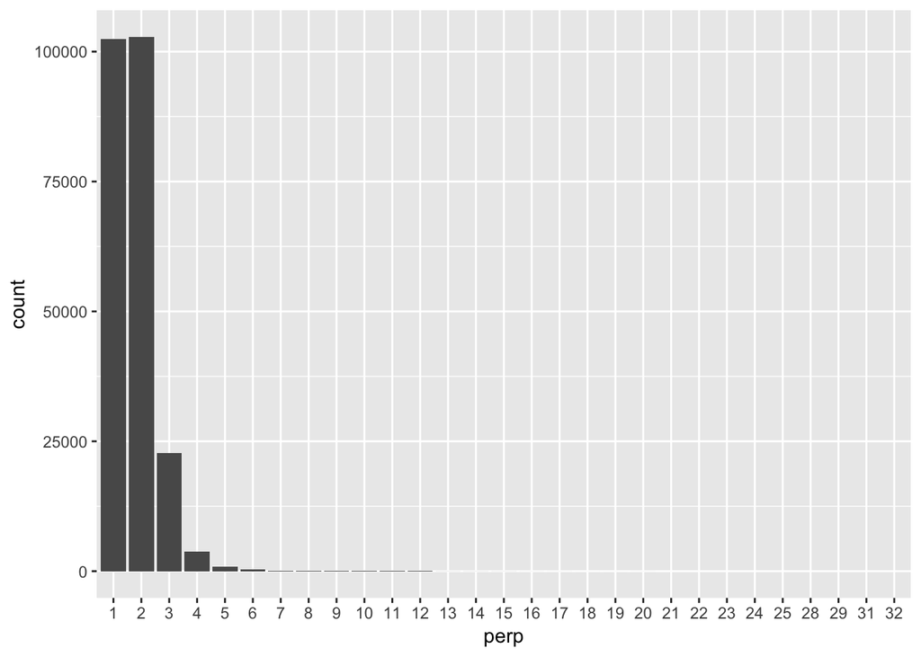

```r
p + geom_bar(aes(x = perp))
```

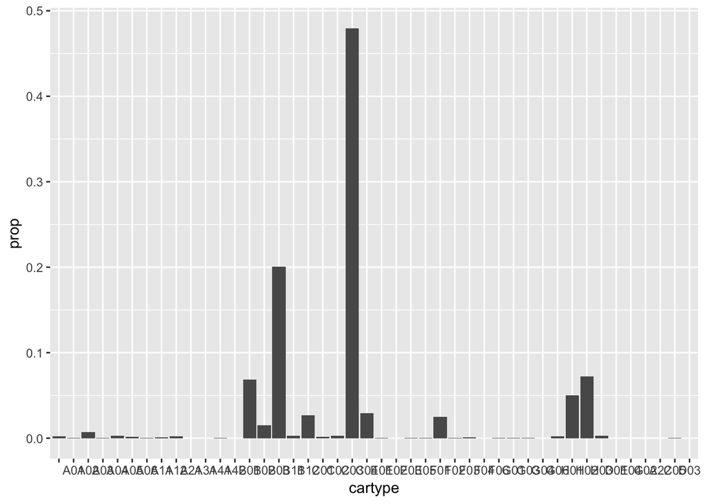

```r
p + geom_bar(aes(x = cartype, y = stat(prop), group = 1))
```

1st: C03 Scooter 2nd: B03 Private small car 3rd: H02 Passenger 4th: B01 Taxi 5th: H01 Pedestrian

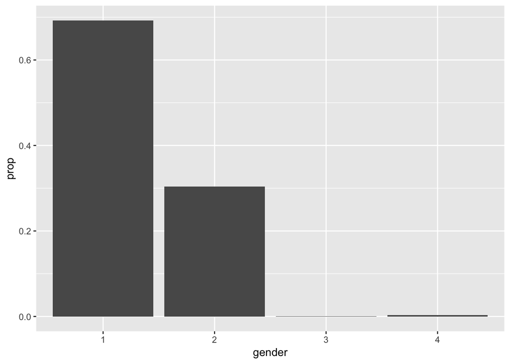

```r
p + geom_bar(aes(x = gender, y = stat(prop), group = 1))
```

Apparently male encounters traffic accidents twice more than female.

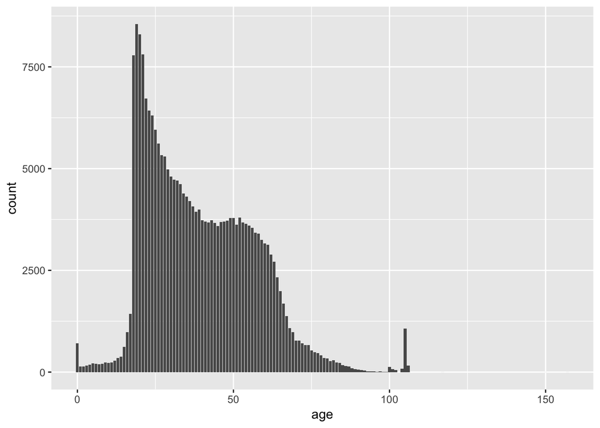

```r
p + geom_bar(aes(x = age))
```

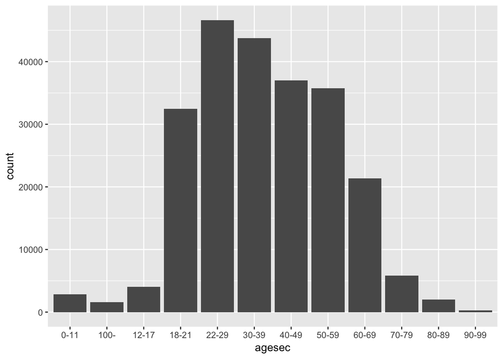

```r
p + geom_bar(aes(x = agesec))
```

People under 18 are illegal to drive, so people under 18 are less likely to get into traffic accidents.

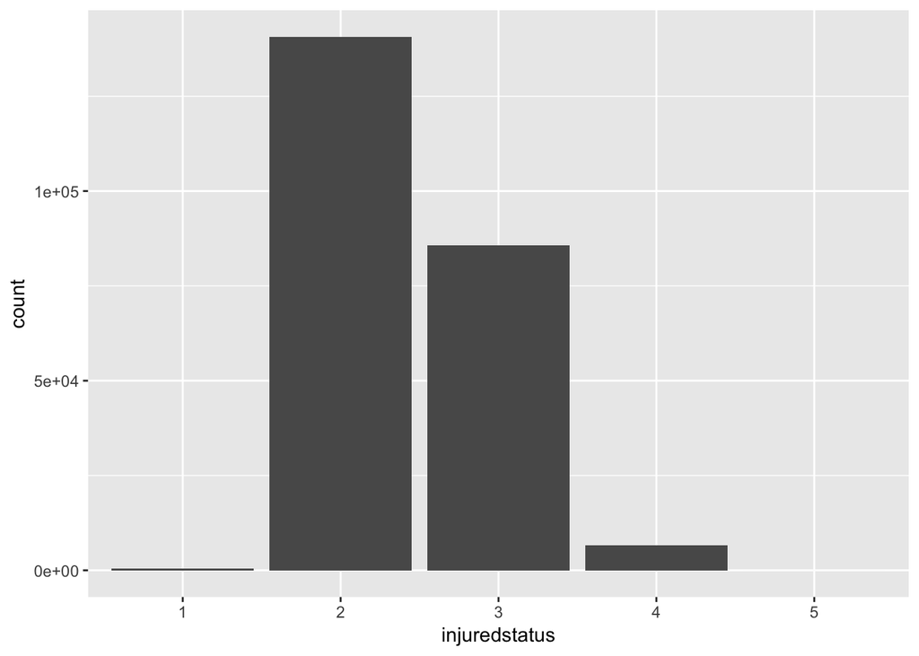

```r
p + geom_bar(aes(x = injuredstatus))
```

1: died within 24 hr 2: injured 3: safe & sound 4: unknown 5: die within 2-30 days

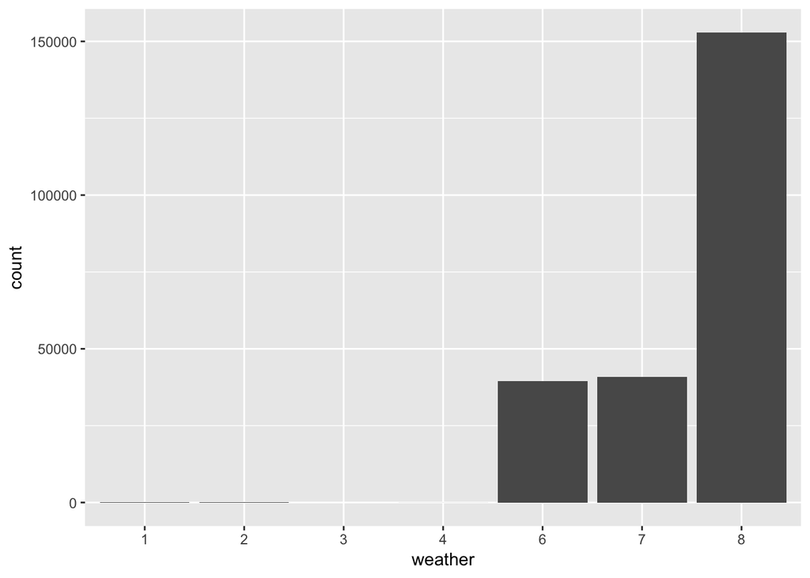

```r
p + geom_bar(aes(x = weather))
```

1-5: Rare weather condition in Taiwan such as storm or snow 6: Rainy 7: Cloudy 8: Sunny - Taiwan has a subtropical climate.

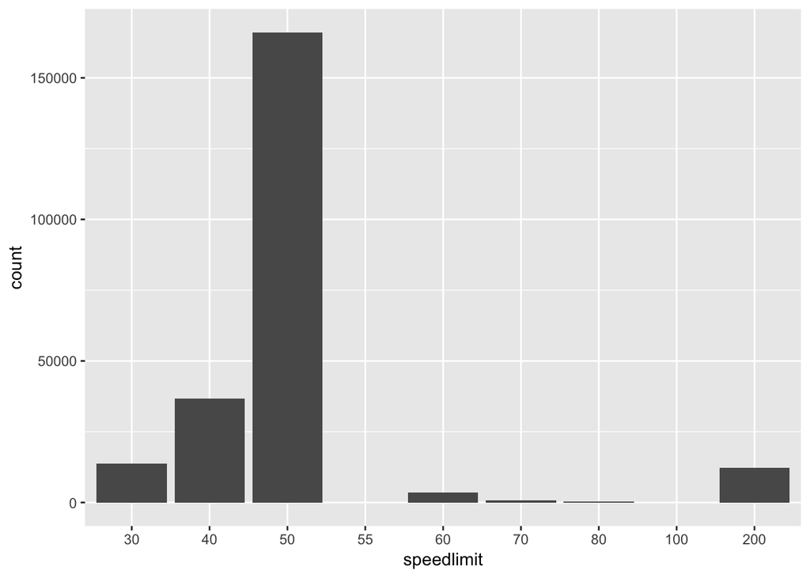

```r
p + geom_bar(aes(x = speedlimit))
```

Note that we set speedlimit to 200 for locations that do not have any speed limitation.

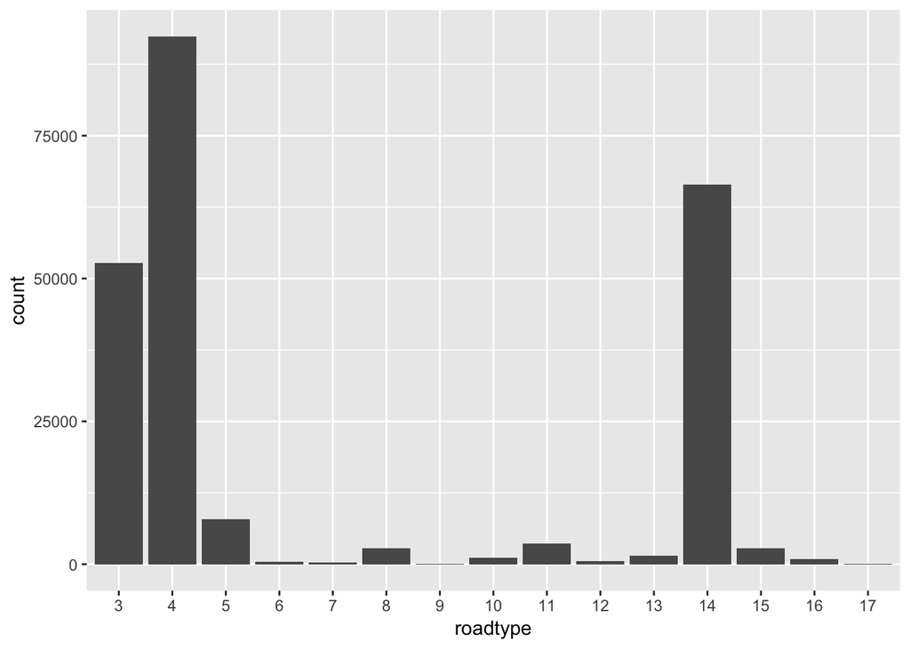

```r
p + geom_bar(aes(x = roadtype))
```

3: 3-way intersection 4: 4-way intersection 14: straight road

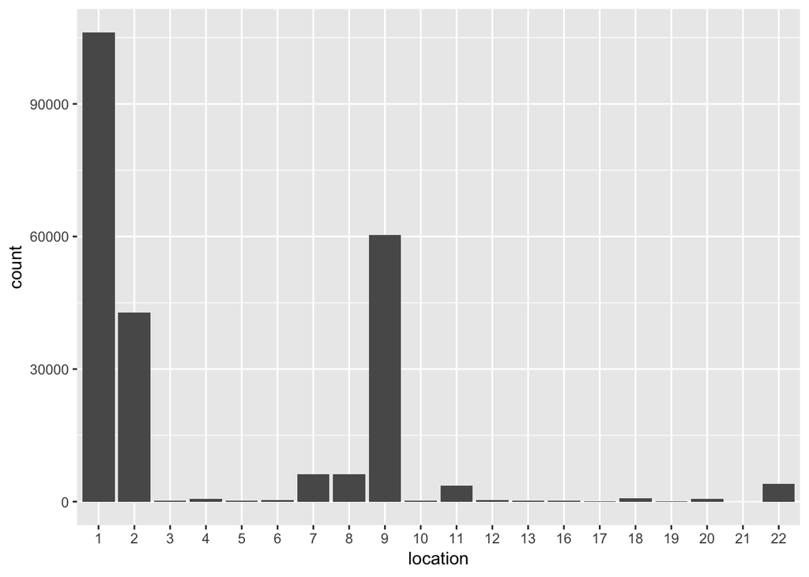

```r
p + geom_bar(aes(x = location))
```

1: inside the intersection 2: near the intersection 7: fast lane 8: slow lane 9: general road without specifying fast lane and slow lane

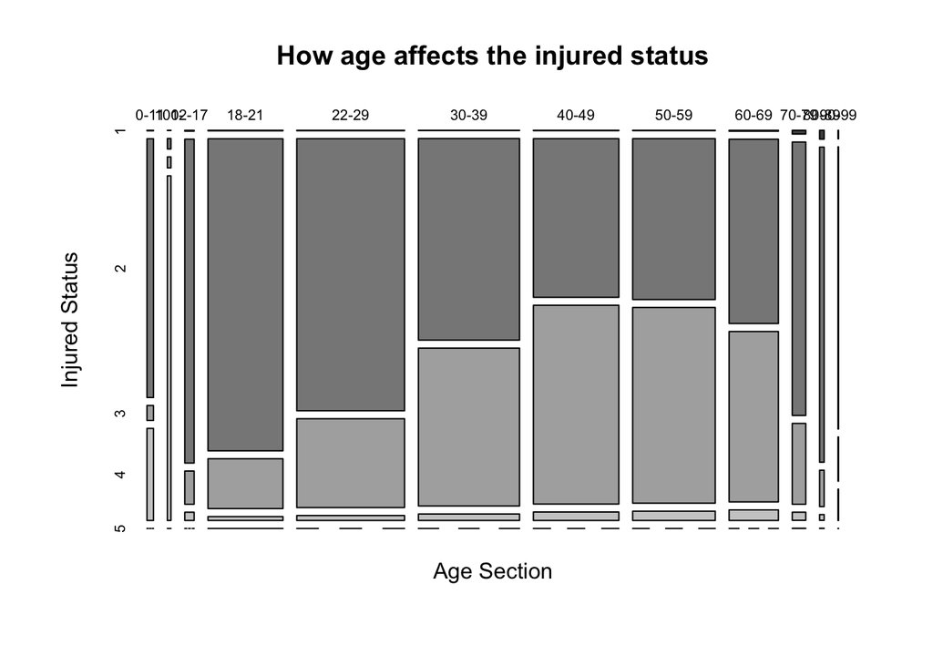

```r
mosaicplot(table(t$agesec, t$injuredstatus), color = TRUE, main = "How age affects the injured status", xlab = "Age Section", ylab = "Injured Status")
```

2: Injured 3: Safe & sound

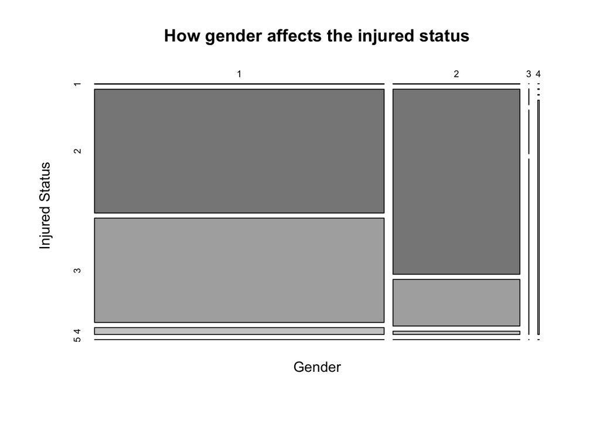

```r
mosaicplot(table(t$gender, t$injuredstatus), color = TRUE, main = "How gender affects the injured status", xlab = "Gender", ylab = "Injured Status")
```

Higher proportion of female get injured in a traffic accident than that of male, which might result from the fact that most vehicles are designed for male instead of female, thus making female more dangerous when driving a car.